# Robotic insertion sort: inferred loop invariants with RoboVerify

**Research question.** Can RoboVerify infer useful outer- and inner-loop invariants from executions of a Fetch robot sorting keyed blocks, and do those *actual learned formulas* survive symbolic preservation checks?

This notebook connects **physical execution → immutable snapshots → relational predicates → RoboVerify inference → held-out evaluation → symbolic induction**. Four 5 cm cubes occupy a row of slots 11 cm apart. A temporary buffer holds the selected block while larger keys shift right. Sorting order is increasing world **y**.

The numerical execution uses `FetchPickAndPlaceConstruction` and real `pick → move → release` actions through `env.step()`. Poses are assigned directly only for scene initialization/reset. The notebook records an MP4 and a measured loop-state figure.

**Evidence labels used throughout:** learned clauses come from RoboVerify; predicate definitions and structural conditions are supplied by us; held-out results concern simulation runs; symbolic results concern a fixed four-block abstraction under successful-transfer contracts. Controller reliability, physical deployment, arbitrary block counts, and a formal proof of the Python-to-model translation are outside this claim.

## 1. Reproducible runtime and scene configuration

Run all cells with this project’s `.venv` kernel. On a fresh Apple Silicon checkout, run `uv sync` and `uv run python3 -m scripts.setup_mujoco_macos` from `roboverify` first. The project-local MuJoCo setup must precede simulator imports.

```python
from pathlib import Path
import inspect
import os
import sys

# Must precede simulator imports (see the project's AGENTS.md).
os.environ.pop("LD_PRELOAD", None)

import numpy as np
import z3

PROJECT_ROOT = next(
    (root for parent in [Path.cwd(), *Path.cwd().parents]
     for root in (parent, parent / "roboverify")
     if (root / "synthesis/environment/cee_us_env/fpp_construction_env.py").is_file()),
    None,
)
if PROJECT_ROOT is None:
    raise RuntimeError("Run this notebook from the RoboVerify repository.")
if str(PROJECT_ROOT) not in sys.path:
    sys.path.insert(0, str(PROJECT_ROOT))
```

```python
# Scene configuration. Positions below are offsets in meters.
NUM_BLOCKS = 4
SEED = 42
ROW_X_OFFSET = 0.10
SLOT_SPACING = 0.11
SLOT_Y_OFFSETS = (np.arange(NUM_BLOCKS) - (NUM_BLOCKS - 1) / 2) * SLOT_SPACING
IMAGE_WIDTH = 960
IMAGE_HEIGHT = 720
IMAGE_PATH = PROJECT_ROOT / "notebooks/robotic_insertion_sort_initial_state.png"

assert SLOT_SPACING > 0.05  # Cubes are 5 cm wide in the existing scene XML.
assert abs(ROW_X_OFFSET) <= 0.15
assert np.max(np.abs(SLOT_Y_OFFSETS)) <= 0.18  # Validated reachable row for four blocks.
VIDEO_PATH = PROJECT_ROOT / "notebooks/robotic_insertion_sort.mp4"
FINAL_IMAGE_PATH = PROJECT_ROOT / "notebooks/robotic_insertion_sort_final.png"
REPORT_PATH = PROJECT_ROOT / "notebooks/robotic_insertion_sort_result.json"
```

```python
# Configure the project-local runtime before importing mujoco_py.
from synthesis.environment.cee_us_env.runtime import configure_local_mujoco

mujoco_path = configure_local_mujoco()
if not mujoco_path.is_dir():
    raise RuntimeError(
        f"MuJoCo runtime missing at {mujoco_path}. "
        "On Apple Silicon, run: uv run python3 -m scripts.setup_mujoco_macos"
    )

from synthesis.environment.cee_us_env.fpp_construction_env import FetchPickAndPlaceConstruction

print(f"MuJoCo runtime: {mujoco_path}")
```

```
MuJoCo runtime: /Users/luoninz1/Documents/RoboVerify/roboverify/.runtime/mujoco211
```

## 2. Initialize stable block identities and the shuffled row

Keys remain attached to physical block names within each run. `order` records the program’s intended slot assignment; later predicates obtain physical occupancy independently from MuJoCo poses. The baseline includes actuator/mocap inputs as well as simulator state.

```python
# Initialize one Fetch arm and four keyed blocks in a shuffled row.

# Close the previous simulator when rerunning this cell.
if "env" in globals():
    env.close()

# The existing class samples with NumPy's global RNG; its seed() is a no-op.
np.random.seed(SEED)

env = FetchPickAndPlaceConstruction(
    name="robotic_insertion_sort_initial_scene",
    sparse=False,
    shaped_reward=False,
    num_blocks=NUM_BLOCKS,
    reward_type="sparse",
    case="PickAndPlace",
    simple=True,
    visualize_target=False,
    visualize_mocap=False,
)

try:
    env.reset()  # Legacy API: returns observation only.
    slot_positions = np.column_stack((
        np.full(NUM_BLOCKS, env.initial_gripper_xpos[0] + ROW_X_OFFSET),
        env.initial_gripper_xpos[1] + SLOT_Y_OFFSETS,
        np.full(NUM_BLOCKS, env.height_offset),
    ))

    # Keys stay attached to physical block identities, while slot order is shuffled.
    keys = {name: i + 1 for i, name in enumerate(env.object_names)}
    initial_order = tuple(str(name) for name in np.random.default_rng(SEED).permutation(env.object_names))
    block_positions = np.empty_like(slot_positions)  # Indexed by physical object ID.
    for slot, name in enumerate(initial_order):
        block_positions[env.object_names.index(name)] = slot_positions[slot]
    buffer_position = np.array([
        slot_positions[0, 0] - 0.18, env.initial_gripper_xpos[1], env.height_offset
    ])

    # Set each free joint's position and identity quaternion, and clear velocity.
    for name, position in zip(env.object_names, block_positions):
        env.sim.data.set_joint_qpos(
            f"{name}:joint", np.concatenate((position, [1.0, 0.0, 0.0, 0.0]))
        )
        env.sim.data.set_joint_qvel(f"{name}:joint", np.zeros(6))
    env.sim.forward()

    # Keep unused pick-and-place goals consistent with this initial layout.
    env.goal = np.concatenate((block_positions.ravel(), np.zeros(3)))
    observation = env.flatten_observation(env._get_obs())
    initial_state = env.get_GT_state().copy()
    # A full restart also restores inputs omitted by legacy get_GT_state().
    initial_inputs = {
        attr: getattr(env.sim.data, attr).copy()
        for attr in ("ctrl", "mocap_pos", "mocap_quat", "qacc_warmstart", "qfrc_applied", "xfrc_applied")
    }

    # Check actual simulator geometry, not just the requested coordinates.
    actual_positions = np.array([
        env.sim.data.get_site_xpos(name).copy() for name in env.object_names
    ])
    half_sizes = np.array([
        env.sim.model.geom_size[env.sim.model.geom_name2id(name)].copy()
        for name in env.object_names
    ])
    table_id = env.sim.model.geom_name2id("table0")
    table_height = env.sim.data.geom_xpos[table_id, 2]  # table0 is a plane.
    assert len(env.object_names) == NUM_BLOCKS
    assert np.isfinite(observation).all()
    np.testing.assert_allclose(actual_positions, block_positions, atol=1e-6)
    np.testing.assert_allclose(actual_positions[:, 2] - half_sizes[:, 2], table_height, atol=2e-3)
    for i in range(NUM_BLOCKS):
        for j in range(i):
            assert np.any(
                np.abs(actual_positions[i, :2] - actual_positions[j, :2])
                > half_sizes[i, :2] + half_sizes[j, :2]
            ), f"Blocks {i} and {j} overlap."
    grip_position = env.sim.data.get_site_xpos("robot0:grip").copy()
    assert grip_position[2] > np.max(actual_positions[:, 2] + half_sizes[:, 2])

    print("Initial keys by row slot:", [keys[name] for name in initial_order])
    print("Initial block centers (world x, y, z; meters):")
    for name, position in zip(env.object_names, actual_positions):
        print(f"{name}, key={keys[name]}: {np.round(position, 4)}")
except Exception:
    env.close()
    raise

# Restore the same shuffled scene before each sorting run.
def reset_initial_scene():
    """Restore the fixed row; env.reset() instead samples a new random layout."""
    env.set_GT_state(initial_state.copy())
    for attr, values in initial_inputs.items():
        getattr(env.sim.data, attr)[:] = values
    env.sim.forward()
    return env.flatten_observation(env._get_obs())
```

```
Initial keys by row slot: [4, 3, 2, 1]
Initial block centers (world x, y, z; meters):
object0, key=1: [1.4444 0.9141 0.4246]
object1, key=2: [1.4444 0.8041 0.4246]
object2, key=3: [1.4444 0.6941 0.4246]
object3, key=4: [1.4444 0.5841 0.4246]
```

```
Creating offscreen glfw
```

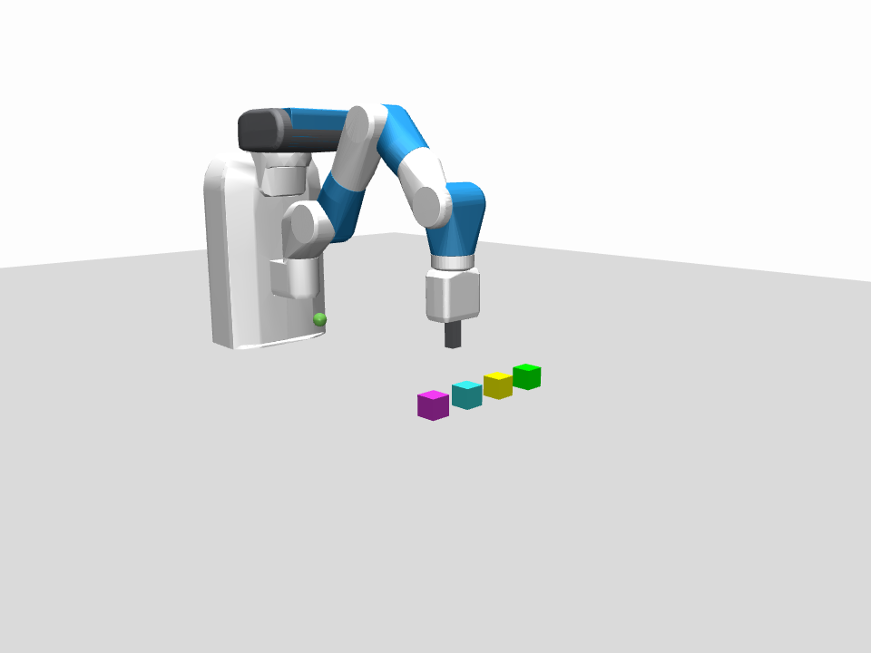

```
Saved initial state: /Users/luoninz1/Documents/RoboVerify/roboverify/notebooks/robotic_insertion_sort_initial_state.png
```

```python
# Render the actual simulator state and display/save the same RGB image.
import imageio.v2 as imageio
from IPython.display import Image, display

try:
    initial_frame = env.render(mode="rgb_array", width=IMAGE_WIDTH, height=IMAGE_HEIGHT)
    assert initial_frame.shape == (IMAGE_HEIGHT, IMAGE_WIDTH, 3)
    assert initial_frame.dtype == np.uint8
    assert np.ptp(initial_frame) > 0, "Renderer returned a blank image."
    imageio.imwrite(IMAGE_PATH, initial_frame)
    display(Image(data=IMAGE_PATH.read_bytes()))
    print(f"Saved initial state: {IMAGE_PATH}")
except Exception:
    env.close()
    raise
```

## 3. Execute the robotic insertion-sort program and record a video

`transfer` is a composite action: `pick`, `move`, then `release`. After a successful transfer, the program updates its logical row. The observer records only coherent loop heads: before selecting the next block, and before each inner guard evaluation after bookkeeping and `j` updates. It also records an explicit outer exit with prefix length `n`; this does not claim that Python's `for` variable becomes `n`.

The exact implementation below is the program used for both the video and the inference corpus. The observer reads state and does not issue robot actions. See implementation and trace adapter.

```python
from IPython.display import Code
from synthesis.examples.robotic_insertion_sort import (
    TableRobot, SortVideo, block_position, insertion_sort_blocks,
)

# Display the exact insertion-sort implementation used by the next cell.
display(Code(inspect.getsource(insertion_sort_blocks), language="python"))
```

```
def insertion_sort_blocks(
    order: list[str | None],
    keys: Mapping[str, int],
    slots: NDArray[np.float64],
    buffer_position: NDArray[np.float64],
    robot: BlockTransferRobot,
    *,
    observer: SortObserver | None = None,
) -> list[str]:
    """Stable insertion sort with a physical buffer for the selected block.

    Args:
        order: Mutable slot-to-block-name list, populated with strings on entry.
            During sorting, None temporarily marks the empty slot.
        keys: Mapping from each block name to its integer sorting key.
        slots: Float64 array of shape (len(order), 3), containing slot XYZ positions.
        buffer_position: Float64 array of shape (3,), containing the buffer XYZ position.
        robot: Object providing transfer() and check_slots(), such as TableRobot.
        observer: Optional trace callback; receives loop-head and explicit exit states.

    Returns:
        The same list, sorted in place by ascending key. On successful return,
        every element is a block name (there are no remaining None entries).
    """
    # Insert each block into the sorted prefix order[:i]; a single first block is already sorted.
    for i in range(1, len(order)):
        # Observe before the guard, including iterations that skip all transfers.
        if observer is not None:
            observer("outer_head", i=i, j=None, selected=None, order=tuple(order))
        # Save this block's name; cast tells the type checker it is str without converting or checking it.
        selected = cast(str, order[i])
        # Look up sorting keys by block name: if the largest prefix key is <= this key, it already fits.
        if keys[cast(str, order[i - 1])] <= keys[selected]:
            # Skip all movement for this block and proceed to the next outer-loop iteration.
            continue
        # Pick, move, and release the selected block in the buffer; the f-string describes this action.
        robot.transfer(selected, buffer_position, f"i={i}: save key {keys[selected]} in buffer")
        # Record the newly empty row slot; the selected block's name is still stored in selected.
        order[i] = None
        # Check that every named block in order is physically at its assigned slot, within tolerance.
```

[output cut: 21 more lines]

```
            if observer is not None:
                observer("inner_head", i=i, j=j, selected=selected, order=tuple(order))
        # Move the buffered block into the vacancy, after all smaller or equal keys in the prefix.
        robot.transfer(selected, slots[j + 1], f"i={i}: insert key {keys[selected]} into slot {j + 1}")
        # Record the selected block in its insertion slot; the row now has no vacancy.
        order[j + 1] = selected
        # Verify all occupied slots again after completing the insertion.
        robot.check_slots(order)
        # Check every adjacent key pair in order[:i + 1]; raise AssertionError if this prefix is unsorted.
        assert all(keys[cast(str, order[k])] <= keys[cast(str, order[k + 1])] for k in range(i))
    # Python's for-loop index stops at n - 1; the exit prefix length is explicitly n.
    if observer is not None:
        observer("outer_exit", i=len(order), j=None, selected=None, order=tuple(order))
    # Return the same, now-sorted list; cast declares that no None entries remain without copying the list.
    return cast(list[str], order)
```

```python
import json
from dataclasses import asdict
from synthesis.examples.robotic_sort_traces import PhysicalTraceRecorder, capture_simulator_state

reset_initial_scene()
experiment_baseline = capture_simulator_state(env)
order = list(initial_order)
robot = TableRobot(env, slot_positions, keys)
recorder = SortVideo(env, keys, slot_positions, buffer_position, VIDEO_PATH,
                     width=IMAGE_WIDTH, height=IMAGE_HEIGHT, stride=2)
robot.recorder = recorder
demo_trace = PhysicalTraceRecorder(env, slot_positions, buffer_position, keys, initial_order,
                                   robot, case_name="video_seed_42")

try:
    recorder.pause(robot, seconds=2)
    insertion_sort_blocks(order, keys, slot_positions, buffer_position, robot, observer=demo_trace)

    # Independently measure the final physical ordering instead of trusting order.
    physical_order = sorted(env.object_names, key=lambda name: block_position(env, name)[1])
    final_keys = [keys[name] for name in physical_order]
    assert final_keys == sorted(keys.values())
    assert physical_order == order
    assert sorted(physical_order) == sorted(initial_order)
    assert robot.held is None
    robot.check_slots(physical_order)

    final_positions = np.array([block_position(env, name) for name in physical_order])
    max_position_error = float(np.max(np.linalg.norm(final_positions - slot_positions, axis=1)))
    for name in physical_order:
        rotation = env.sim.data.get_site_xmat(name)
        assert rotation[2, 2] > 0.98, f"{name} is tilted."
    assert all(np.linalg.norm(block_position(env, name) - buffer_position) > 0.05
               for name in physical_order)

    robot.description = f"Sorted: {final_keys} — all four blocks verified in their row slots"
    robot.phase = "Complete: physical order, table heights, upright poses, and empty buffer checked"
    recorder.pause(robot, seconds=3)
    imageio.imwrite(FINAL_IMAGE_PATH, recorder.frame(robot))
finally:
    robot.recorder = None
    recorder.close()

report = {
    "seed": SEED,
    "keys": keys,
    "initial_order": list(initial_order),
    "initial_keys": [keys[name] for name in initial_order],
    "final_order": physical_order,
    "final_keys": final_keys,
    "slot_positions": slot_positions.tolist(),
    "final_positions": final_positions.tolist(),
    "max_position_error_m": max_position_error,
    "simulation_steps": robot.steps,
    "simulation_seconds": robot.steps * env.dt,
    "video_frames": recorder.frames,
    "video_fps": recorder.fps,
    "transfers": robot.transfers,
    "verified": True,
}
REPORT_PATH.write_text(json.dumps(report, indent=2) + "\n")
print(f"Sorted {[keys[name] for name in initial_order]} -> {final_keys}")
print(f"{len(robot.transfers)} physical transfers; {robot.steps} simulation steps")
print(f"Largest slot-position error: {1000 * max_position_error:.2f} mm")
print(f"Video: {VIDEO_PATH}")
DEMO_TRACE_PATH = PROJECT_ROOT / "notebooks/robotic_insertion_sort_demo_trace.json"
DEMO_TRACE_PATH.write_text(json.dumps([asdict(state) for state in demo_trace.snapshots], indent=2) + "\n")
print(f"Captured {len(demo_trace.snapshots)} coherent loop-boundary snapshots.")
```

```
i=1: save key 3 in buffer
```

```
i=1: shift key 4 from slot 0 to 1
```

```
i=1: insert key 3 into slot 0
```

```
i=2: save key 2 in buffer
```

```
i=2: shift key 4 from slot 1 to 2
```

```
i=2: shift key 3 from slot 0 to 1
```

```
i=2: insert key 2 into slot 0
```

```
i=3: save key 1 in buffer
```

```
i=3: shift key 4 from slot 2 to 3
```

```
i=3: shift key 3 from slot 1 to 2
```

```
i=3: shift key 2 from slot 0 to 1
```

```
i=3: insert key 1 into slot 0
```

```
Sorted [4, 3, 2, 1] -> [1, 2, 3, 4]
12 physical transfers; 1975 simulation steps
Largest slot-position error: 2.49 mm
Video: /Users/luoninz1/Documents/RoboVerify/roboverify/notebooks/robotic_insertion_sort.mp4
Captured 13 coherent loop-boundary snapshots.
```

[video not shown]

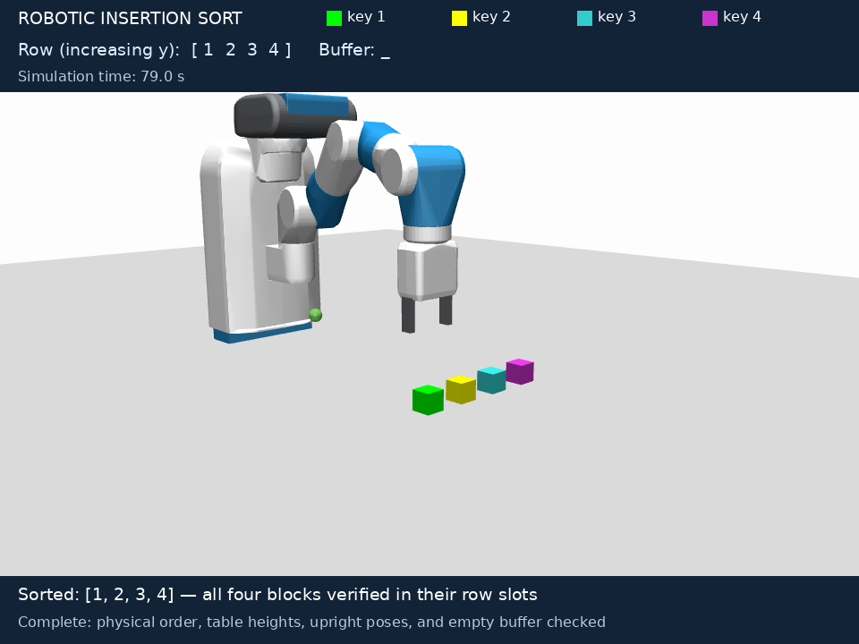

```python
from IPython.display import Video

# MP4 is embedded so the executed notebook can play it without a file server.
display(Video(filename=str(VIDEO_PATH), embed=True, width=IMAGE_WIDTH))
display(Image(filename=str(FINAL_IMAGE_PATH)))
```

## 4. Inspect the measured loop states

Each row below is a captured simulator state. Numbers are block keys obtained from **measured occupancy**; `–` is a vacancy. Inner-loop rows contain one buffered block and one vacant row slot. The video timestamp includes its two-second initial pause.

```python
from html import escape
from IPython.display import HTML, Markdown, display

def show_table(headers, rows):
    head = "".join(f"<th>{escape(str(value))}</th>" for value in headers)
    body = "".join("<tr>" + "".join(f"<td>{escape(str(value))}</td>" for value in row) + "</tr>" for row in rows)
    display(HTML(f"<table><thead><tr>{head}</tr></thead><tbody>{body}</tbody></table>"))

demo_rows = []
for state in demo_trace.snapshots:
    occupancy = {location: state.key_map[name] for name, location in state.locations.items()}
    demo_rows.append([state.program_point, state.i, state.j,
                      *[occupancy.get(slot, "–") for slot in range(NUM_BLOCKS)],
                      occupancy.get("buffer", "–"), f"{2 + state.step * env.dt:.2f}"])
show_table(["Program point", "i / prefix", "j", "Slot 0", "Slot 1", "Slot 2", "Slot 3", "Buffer", "Video seconds"], demo_rows)
```

| Program point | i / prefix | j | Slot 0 | Slot 1 | Slot 2 | Slot 3 | Buffer | Video seconds |
| --- | --- | --- | --- | --- | --- | --- | --- | --- |
| outer_head | 1 | None | 4 | 3 | 2 | 1 | – | 2.00 |
| inner_head | 1 | 0 | 4 | – | 2 | 1 | 3 | 8.88 |
| inner_head | 1 | -1 | – | 4 | 2 | 1 | 3 | 15.20 |
| outer_head | 2 | None | 3 | 4 | 2 | 1 | – | 21.84 |
| inner_head | 2 | 1 | 3 | 4 | – | 1 | 2 | 28.52 |
| inner_head | 2 | 0 | 3 | – | 4 | 1 | 2 | 34.88 |
| inner_head | 2 | -1 | – | 3 | 4 | 1 | 2 | 41.36 |
| outer_head | 3 | None | 2 | 3 | 4 | 1 | – | 48.00 |
| inner_head | 3 | 2 | 2 | 3 | 4 | – | 1 | 55.12 |
| inner_head | 3 | 1 | 2 | 3 | – | 4 | 1 | 61.48 |
| inner_head | 3 | 0 | 2 | – | 3 | 4 | 1 | 67.96 |
| inner_head | 3 | -1 | – | 2 | 3 | 4 | 1 | 74.40 |
| outer_exit | 4 | None | 1 | 2 | 3 | 4 | – | 81.00 |

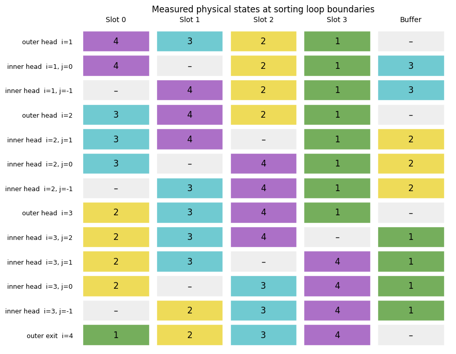

```python
import matplotlib.pyplot as plt
from matplotlib.patches import Rectangle

fig, ax = plt.subplots(figsize=(9, 7))
palette = {1: "#75ae5c", 2: "#eedb58", 3: "#70cad1", 4: "#ac70c7"}
for row, state in enumerate(demo_trace.snapshots):
    occupancy = {location: state.key_map[name] for name, location in state.locations.items()}
    for column, location in enumerate([0, 1, 2, 3, "buffer"]):
        key = occupancy.get(location)
        ax.add_patch(Rectangle((column, row), .9, .85,
                              facecolor=palette.get(key, "#eeeeee"), edgecolor="white"))
        ax.text(column + .45, row + .425, str(key) if key is not None else "–",
                ha="center", va="center", fontsize=12)
labels = [f"{s.program_point.replace('_', ' ')}  i={s.i}" + (f", j={s.j}" if s.j is not None else "")
          for s in demo_trace.snapshots]
ax.set_yticks([index + .425 for index in range(len(labels))], labels, fontsize=9)
ax.set_xticks([index + .45 for index in range(5)], ["Slot 0", "Slot 1", "Slot 2", "Slot 3", "Buffer"])
ax.xaxis.tick_top()
ax.set(xlim=(-.1, 5), ylim=(len(labels), -.2), title="Measured physical states at sorting loop boundaries")
ax.tick_params(length=0)
for spine in ax.spines.values():
    spine.set_visible(False)
fig.tight_layout()
TRACE_FIGURE_PATH = PROJECT_ROOT / "notebooks/robotic_insertion_sort_invariant_trace.png"
fig.savefig(TRACE_FIGURE_PATH, dpi=180, bbox_inches="tight")
plt.show()
```

## 5. Relational vocabulary and abstraction semantics

The entity universe is the set of **physical block names**, including the buffered block. It excludes the `None` vacancy. Snapshots copy keys, positions, orientations, logical order, initial order, indices, selected identity, and gripper state.

| Predicate | Concrete meaning | Scope |
| --- | --- | --- |
| `KeyLE(x,y)` | Integer key of x ≤ integer key of y | Both loops |
| `Before(x,y)` | Both occupy measured row slots and slot(x) < slot(y) | Both loops |
| `Processed(x)` | x belongs to logical `order[:i]` | Outer |
| `InRow(x)` | Pose matches one row slot | Both |
| `InBuffer(x)` | Pose matches the buffer | Both |
| `AtAssignedSlot(x)` | Measured slot equals x's logical row slot; false for buffered x | Both |
| `Active(x)` | Measured row slot lies in 0..i | Inner |
| `Shifted(x)` | Measured row slot lies in j+2..i | Inner |

The inner-loop `selected` is a **state constant**, bound separately in every snapshot. `k=2` means two universally quantified objects, not two blocks in the scene.

For center positions p and slot s, placement means

$$ (p_x-s_x)^2+(p_y-s_y)^2\leq 0.012^2 \quad\land\quad |p_z-s_z|\leq 0.005. $$

An unmatched or ambiguous pose fails abstraction validation instead of being forced into the nearest slot. Domain evaluators return Python Boolean values. The symbolic model interprets predicates over the decoded discrete locations; it does not encode MuJoCo dynamics or floating-point coordinates. The geometric decoding and successful-transfer contract connect those locations to simulator measurements; on.py illustrates the concrete/Z3 predicate pattern.

**Axioms:** `KeyLE` is a total preorder, allowing equal keys on different identities. `Before` is irreflexive/transitive and total only for pairs satisfying `InRow`; it is false for off-row arguments. Row/buffer membership is disjoint, and `AtAssignedSlot ⇒ InRow`. Sortedness, shifted-key comparisons, and selected-buffer identity are **not axioms or whole-property input features**.

## 6. Collect independent physical training and held-out runs

The base corpus covers all 24 permutations of four distinct keys plus eight tie/negative-key cases. Splits are assigned by whole execution, before inference. A solver-derived refinement case is added to training; held-out runs remain unchanged. Every run uses the actual controller, with full simulator reset between cases.

This cell runs the full physical corpus again. It writes incremental JSON evidence, including any failed cases; failed executions are reported rather than silently omitted from the success claim.

| Name | Meaning | Example |
| --- | --- | --- |
| `permutation_XX` | One of the (4! = 24) arrangements of distinct keys `1, 2, 3, 4`. `XX` is its zero-based index. | `permutation_03`: `(1, 3, 4, 2)` |
| `train_ties_X` | A **training** case containing equal keys. “Ties” means different blocks share the same sorting key. | `(2, 1, 2, 1)` |
| `held_out_ties_X` | An equal-key case reserved for checking the inferred formulas, without supplying its snapshots to the learner. | `(2, 1, 1, 2)` |
| `refinement_01_equal_suffix` | An additional training case introduced after symbolic verification found a weakness in the first inferred invariant. | `(1, 0, 1, 1)` |

```python
from synthesis.examples.robotic_sort_experiment import collect_corpus, corpus_snapshots, infer_and_validate

TRACES_PATH = PROJECT_ROOT / "notebooks/robotic_insertion_sort_traces.json"
INVARIANTS_PATH = PROJECT_ROOT / "notebooks/robotic_insertion_sort_invariants.json"
corpus = collect_corpus(env, slot_positions, buffer_position, experiment_baseline, TRACES_PATH)
show_table(["Run", "Split", "Initial row keys", "Status", "Steps", "Snapshots"],
           [[record["name"], record["split"], record["keys"], record["status"],
             record.get("run", {}).get("steps", "–"), len(record.get("run", {}).get("snapshots", []))]
            for record in corpus["cases"]])
assert all(record["status"] == "passed" for record in corpus["cases"])
training_states = corpus_snapshots(corpus, "train")
held_out_states = corpus_snapshots(corpus, "held_out")
assert {s.case_name for s in training_states}.isdisjoint({s.case_name for s in held_out_states})
print(f"Training snapshots: {len(training_states)}; held-out snapshots: {len(held_out_states)}")
```

```
Physical case 1/33: permutation_00 train (1, 2, 3, 4)
```

```
  passed (0 steps, 4 snapshots)
```

```
Physical case 2/33: permutation_01 held_out (1, 2, 4, 3)
```

```
  passed (502 steps, 6 snapshots)
```

```
Physical case 3/33: permutation_02 train (1, 3, 2, 4)
```

```
  passed (495 steps, 6 snapshots)
```

```
Physical case 4/33: permutation_03 held_out (1, 3, 4, 2)
```

```
  passed (664 steps, 7 snapshots)
```

```
Physical case 5/33: permutation_04 train (1, 4, 2, 3)
```

```
  passed (987 steps, 8 snapshots)
```

```
Physical case 6/33: permutation_05 held_out (1, 4, 3, 2)
```

```
  passed (1149 steps, 9 snapshots)
```

```
Physical case 7/33: permutation_06 train (2, 1, 3, 4)
```

```
  passed (496 steps, 6 snapshots)
```

```
Physical case 8/33: permutation_07 held_out (2, 1, 4, 3)
```

```
  passed (997 steps, 8 snapshots)
```

```
Physical case 9/33: permutation_08 train (2, 3, 1, 4)
```

```
  passed (658 steps, 7 snapshots)
```

```
Physical case 10/33: permutation_09 held_out (2, 3, 4, 1)
```

```
  passed (826 steps, 8 snapshots)
```

```
Physical case 11/33: permutation_10 train (2, 4, 1, 3)
```

```
  passed (1160 steps, 9 snapshots)
```

```
Physical case 12/33: permutation_11 held_out (2, 4, 3, 1)
```

```
  passed (1311 steps, 10 snapshots)
```

```
Physical case 13/33: permutation_12 train (3, 1, 2, 4)
```

```
  passed (987 steps, 8 snapshots)
```

```
Physical case 14/33: permutation_13 held_out (3, 1, 4, 2)
```

```
  passed (1159 steps, 9 snapshots)
```

```
Physical case 15/33: permutation_14 train (3, 2, 1, 4)
```

```
  passed (1150 steps, 9 snapshots)
```

```
Physical case 16/33: permutation_15 held_out (3, 2, 4, 1)
```

```
  passed (1321 steps, 10 snapshots)
```

```
Physical case 17/33: permutation_16 train (3, 4, 1, 2)
```

```
  passed (1322 steps, 10 snapshots)
```

```
Physical case 18/33: permutation_17 held_out (3, 4, 2, 1)
```

```
  passed (1484 steps, 11 snapshots)
```

```
Physical case 19/33: permutation_18 train (4, 1, 2, 3)
```

```
  passed (1479 steps, 10 snapshots)
```

```
Physical case 20/33: permutation_19 held_out (4, 1, 3, 2)
```

```
  passed (1641 steps, 11 snapshots)
```

```
Physical case 21/33: permutation_20 train (4, 2, 1, 3)
```

```
  passed (1652 steps, 11 snapshots)
```

```
Physical case 22/33: permutation_21 held_out (4, 2, 3, 1)
```

```
  passed (1802 steps, 12 snapshots)
```

```
Physical case 23/33: permutation_22 train (4, 3, 1, 2)
```

```
  passed (1814 steps, 12 snapshots)
```

```
Physical case 24/33: permutation_23 held_out (4, 3, 2, 1)
```

```
  passed (1975 steps, 13 snapshots)
```

```
Physical case 25/33: train_ties_0 train (2, 1, 2, 1)
```

```
  passed (1159 steps, 9 snapshots)
```

```
Physical case 26/33: train_ties_1 train (2, 2, 2, 2)
```

```
  passed (0 steps, 4 snapshots)
```

```
Physical case 27/33: train_ties_2 train (1, 3, 2, 2)
```

```
  passed (987 steps, 8 snapshots)
```

```
Physical case 28/33: train_ties_3 train (3, 2, 2, 1)
```

```
  passed (1802 steps, 12 snapshots)
```

```
Physical case 29/33: train_ties_4 train (0, -1, 2, -1)
```

```
  passed (1159 steps, 9 snapshots)
```

```
Physical case 30/33: held_out_ties_0 held_out (-2, 4, -2, 1)
```

```
  passed (987 steps, 8 snapshots)
```

```
Physical case 31/33: held_out_ties_1 held_out (2, 1, 1, 2)
```

```
  passed (987 steps, 8 snapshots)
```

```
Physical case 32/33: held_out_ties_2 held_out (3, 3, 1, 2)
```

```
  passed (1322 steps, 10 snapshots)
```

```
Physical case 33/33: refinement_01_equal_suffix train (1, 0, 1, 1)
```

```
  passed (496 steps, 6 snapshots)
```

| Run | Split | Initial row keys | Status | Steps | Snapshots |
| --- | --- | --- | --- | --- | --- |
| permutation_00 | train | (1, 2, 3, 4) | passed | 0 | 4 |
| permutation_01 | held_out | (1, 2, 4, 3) | passed | 502 | 6 |
| permutation_02 | train | (1, 3, 2, 4) | passed | 495 | 6 |
| permutation_03 | held_out | (1, 3, 4, 2) | passed | 664 | 7 |
| permutation_04 | train | (1, 4, 2, 3) | passed | 987 | 8 |
| permutation_05 | held_out | (1, 4, 3, 2) | passed | 1149 | 9 |
| permutation_06 | train | (2, 1, 3, 4) | passed | 496 | 6 |
| permutation_07 | held_out | (2, 1, 4, 3) | passed | 997 | 8 |
| permutation_08 | train | (2, 3, 1, 4) | passed | 658 | 7 |
| permutation_09 | held_out | (2, 3, 4, 1) | passed | 826 | 8 |
| permutation_10 | train | (2, 4, 1, 3) | passed | 1160 | 9 |
| permutation_11 | held_out | (2, 4, 3, 1) | passed | 1311 | 10 |
| permutation_12 | train | (3, 1, 2, 4) | passed | 987 | 8 |
| permutation_13 | held_out | (3, 1, 4, 2) | passed | 1159 | 9 |
| permutation_14 | train | (3, 2, 1, 4) | passed | 1150 | 9 |
| permutation_15 | held_out | (3, 2, 4, 1) | passed | 1321 | 10 |
| permutation_16 | train | (3, 4, 1, 2) | passed | 1322 | 10 |
| permutation_17 | held_out | (3, 4, 2, 1) | passed | 1484 | 11 |
| permutation_18 | train | (4, 1, 2, 3) | passed | 1479 | 10 |
| permutation_19 | held_out | (4, 1, 3, 2) | passed | 1641 | 11 |
| permutation_20 | train | (4, 2, 1, 3) | passed | 1652 | 11 |
| permutation_21 | held_out | (4, 2, 3, 1) | passed | 1802 | 12 |
| permutation_22 | train | (4, 3, 1, 2) | passed | 1814 | 12 |
| permutation_23 | held_out | (4, 3, 2, 1) | passed | 1975 | 13 |
| train_ties_0 | train | (2, 1, 2, 1) | passed | 1159 | 9 |
| train_ties_1 | train | (2, 2, 2, 2) | passed | 0 | 4 |
| train_ties_2 | train | (1, 3, 2, 2) | passed | 987 | 8 |
| train_ties_3 | train | (3, 2, 2, 1) | passed | 1802 | 12 |
| train_ties_4 | train | (0, -1, 2, -1) | passed | 1159 | 9 |
| held_out_ties_0 | held_out | (-2, 4, -2, 1) | passed | 987 | 8 |
| held_out_ties_1 | held_out | (2, 1, 1, 2) | passed | 987 | 8 |
| held_out_ties_2 | held_out | (3, 3, 1, 2) | passed | 1322 | 10 |
| refinement_01_equal_suffix | train | (1, 0, 1, 1) | passed | 496 | 6 |

```
Training snapshots: 148; held-out snapshots: 140
```

## 7. Infer the loop invariants with RoboVerify

The existing `infer_relational_invariants` API grounds predicates and invokes RoboVerify's Boolean learner. To control search cost, each loop uses small vocabulary projections; their **actual inferred clauses are conjoined**. No clause is removed manually, and no desired target is inserted into the learned formula.

Outer projections cover pairwise ordering and unary occupancy. Inner projections additionally compare each shifted block to the selected constant. Every projection checks its domain axioms against all training snapshots before invoking inference.

Implementation: relational front end, task-specific inference adapter.

```python
learned, inference_report = infer_and_validate(corpus, INVARIANTS_PATH)
show_table(["Loop", "Projection", "Vocabulary atoms", "Distinct truth rows", "Retained clauses"],
           [[phase, name, len(result.vocabulary), len(result.truth_rows), len(result.clauses)]
            for phase, loop in learned.items() for name, result in loop.projections.items()])
for phase, loop in learned.items():
    display(Markdown(f"**{phase.capitalize()} vocabulary**"))
    for name, result in loop.projections.items():
        print(name + ": " + ", ".join(map(str, result.vocabulary)))
```

```
Inferring outer/ordering: 72 snapshots, k=2
```

```
Inferring outer/physical: 72 snapshots, k=1
```

```
outer: {"axioms_satisfiable": "sat", "axioms_and_candidate_satisfiable": "sat", "target_entailment": {"sorted_prefix": "unsat", "all_blocks_in_assigned_row_slots": "unsat", "empty_buffer": "unsat"}, "snapshots_checked": 60, "violations": [], "all_passed": true}
```

```
Inferring inner/ordering: 76 snapshots, k=2
```

```
Inferring inner/physical: 76 snapshots, k=1
```

```
Inferring inner/shifted_comparison: 76 snapshots, k=1
```

```
inner: {"axioms_satisfiable": "sat", "axioms_and_candidate_satisfiable": "sat", "target_entailment": {"sorted_occupied_active_region": "unsat", "shifted_keys_strictly_greater": "unsat", "selected_is_the_only_buffered_block": "unsat", "other_blocks_in_assigned_row_slots": "unsat"}, "snapshots_checked…
```

| Loop | Projection | Vocabulary atoms | Distinct truth rows | Retained clauses |
| --- | --- | --- | --- | --- |
| outer | ordering | 9 | 18 | 4 |
| outer | physical | 3 | 1 | 2 |
| inner | ordering | 9 | 31 | 4 |
| inner | physical | 7 | 2 | 4 |
| inner | shifted_comparison | 5 | 5 | 1 |

**Outer vocabulary**

```
ordering: Processed(ux1), Processed(ux2), Before(ux1, ux2), Before(ux2, ux1), KeyLE(ux1, ux2), KeyLE(ux2, ux1), InRow(ux1), InRow(ux2), ux1 == ux2
physical: InRow(ux1), InBuffer(ux1), AtAssignedSlot(ux1)
```

**Inner vocabulary**

```
ordering: Active(ux1), Active(ux2), Before(ux1, ux2), Before(ux2, ux1), KeyLE(ux1, ux2), KeyLE(ux2, ux1), InRow(ux1), InRow(ux2), ux1 == ux2
physical: InRow(ux1), InRow(selected), InBuffer(ux1), InBuffer(selected), AtAssignedSlot(ux1), AtAssignedSlot(selected), ux1 == selected
shifted_comparison: Shifted(ux1), Shifted(selected), KeyLE(ux1, selected), KeyLE(selected, ux1), ux1 == selected
```

**How to read the projection table**

A **vocabulary projection** is a small selected set of predicates/atoms through which we view the same loop-state dataset. These are task-specific groups chosen in `infer_loop`, not three built-in categories of invariants in RoboVerify. Each group runs inference independently, using only the atoms and applicable domain axioms in that projection. The groups may overlap. Their names indicate their intended focus, not a restriction on which facts the learner may discover.

| Projection | Predicates | Purpose |
| --- | --- | --- |
| `ordering` | Outer: `Processed`, `Before`, `KeyLE`, `InRow`; inner: replace `Processed` with `Active` | Compare keys of blocks in the relevant ordered region. `InRow` is included because `Before` is defined only for row occupants, and its totality axiom is guarded by row membership. |
| `physical` | `InRow`, `InBuffer`, `AtAssignedSlot` | Learn occupancy and agreement between measured positions and logical assignments. The inner projection also uses the `selected` constant to distinguish the buffered block from every other block. |
| `shifted_comparison` | `Shifted`, `KeyLE`, with `selected` | Inner loop only: learn how the keys of already shifted blocks compare with the buffered block's key. The checked consequence is `Shifted(x) ⇒ ¬KeyLE(x, selected)`, meaning strictly greater. |

**Why `ForAll(ux1, InRow(ux1))` appears twice.** `InRow` belongs to both outer projections. Every captured outer-loop state has every block back in the row, so both independent inference calls can learn the same universally true fact. The ordering learner is allowed to discover this unary fact even though its main purpose is learning order relationships. Redundancy filtering takes place inside each inference call; the adapter does not perform a second global deduplication across projections. It combines the results as

$$I_{outer}=I_{ordering}\land I_{physical},\qquad I_{inner}=I_{ordering}\land I_{physical}\land I_{shifted\_comparison}.$$

The repetition is logically harmless because $P\land P\equiv P$. The table reports retained clauses **per projection**, so adding those counts does not give a count of globally unique or logically independent clauses. The repeated formula is retained in the display to preserve each inference call's provenance. At inner-loop heads, the selected block is in the buffer, so `ForAll(x, InRow(x))` is not a valid inner-loop invariant.

**Why the atom counts are 9, 3, 7, and 5.** A predicate name such as `Before` generates multiple atoms when applied to symbolic terms. Equality is also added automatically because `include_equality=True`.

- `ordering`: two unary predicates applied to `ux1` and `ux2` give 4 atoms; two binary predicates in both argument orders give 4; `ux1 == ux2` adds 1: **9**.
- Outer `physical`: three unary predicates applied to `ux1`, with no selected constant: **3**.
- Inner `physical`: three unary predicates applied to both `ux1` and `selected` give 6; `ux1 == selected` adds 1: **7**.
- `shifted_comparison`: `Shifted(ux1)`, `Shifted(selected)`, `KeyLE(ux1, selected)`, `KeyLE(selected, ux1)`, and `ux1 == selected`: **5**.

These counts follow the current builder, which omits binary applications with syntactically identical arguments. Grounded variables can still refer to the same physical block.

**Distinct truth rows are Boolean patterns, not executions.** After evaluating the chosen atoms for all sampled object assignments, identical Boolean vectors are deduplicated. Outer `physical` has one pattern, `(True, False, True)`, for `InRow`, `InBuffer`, and `AtAssignedSlot`. Inner `physical` has two patterns: the assigned object is either the buffered selected block or another block occupying its assigned row slot. The ordering projections distinguish more patterns of region membership, relative position, key comparisons, and identity.

Implementation: `infer_loop` selects the overlapping projections and conjoins their results; `build_relational_vocabulary` and `build_relational_dataset` construct atoms and deduplicate truth rows.

### 7.1 Inspect the actual learned clauses

These are backend outputs, grouped by projection. The semantic summaries in the next section are verified consequences of these formulas; they are not substituted for the formulas during verification.

```python
for phase, loop in learned.items():
    display(Markdown(f"**{phase.capitalize()} loop — retained formulas**"))
    for projection, result in loop.projections.items():
        print(f"[{projection}]")
        for index, clause in enumerate(result.clauses, 1):
            print(f"\nClause {index}")
            print("expression:")
            print(clause.expr)
            print("target predicate:", clause.target_predicate)
            print("learned via:", clause.learned_via)
    solver = z3.Solver()
    loop.domain.add_axioms(solver)
    solver.add(loop.invariant)
    # Keep phases in separate SMT files: outer and inner invariants need not hold simultaneously.
    smt_path = PROJECT_ROOT / f"notebooks/robotic_insertion_sort_{phase}.smt2"
    smt_path.write_text(solver.sexpr() + "\n(check-sat)\n")
```

**Outer loop — retained formulas**

```
[ordering]

Clause 1
expression:
ForAll([ux1, ux2],
       Or(Not(Processed(ux2)),
          Before(ux2, ux1),
          Processed(ux1)))
target predicate: Processed(ux1)
learned via: phi

Clause 2
expression:
ForAll([ux1, ux2],
       Or(Not(Processed(ux1)),
          Before(ux1, ux2),
          KeyLE(ux2, ux1)))
target predicate: Processed(ux1)
learned via: phi_prime

Clause 3
expression:
ForAll([ux1, ux2],
       Or(Before(ux1, ux2), Before(ux2, ux1), ux1 == ux2))
target predicate: Before(ux1, ux2)
learned via: phi

Clause 4
expression:
ForAll(ux1, InRow(ux1))
target predicate: InRow(ux1)
learned via: phi
[physical]

Clause 1
expression:
ForAll(ux1, InRow(ux1))
target predicate: InRow(ux1)
learned via: phi

Clause 2
expression:
ForAll(ux1, AtAssignedSlot(ux1))
target predicate: AtAssignedSlot(ux1)
learned via: phi
```

**Inner loop — retained formulas**

```
[ordering]

Clause 1
expression:
ForAll([ux1, ux2],
       Or(Active(ux1),
          Not(Active(ux2)),
          Not(Before(ux1, ux2))))
target predicate: Active(ux1)
learned via: phi

Clause 2
expression:
ForAll(ux1, Or(Not(Active(ux1)), InRow(ux1)))
target predicate: Active(ux1)
learned via: phi_prime

Clause 3
expression:
ForAll([ux1, ux2],
       Or(Not(Active(ux1)),
          KeyLE(ux2, ux1),
          Not(Before(ux2, ux1))))
target predicate: Active(ux1)
learned via: phi_prime

Clause 4
expression:
ForAll([ux1, ux2],
       Or(Before(ux1, ux2),
          InRow(ux1),
          InRow(ux2),
          ux1 == ux2))
target predicate: Before(ux1, ux2)
learned via: phi
[physical]

Clause 1
expression:
ForAll(ux1, Or(InRow(ux1), ux1 == selected))
```

[output cut: 13 more lines]

```
learned via: phi

Clause 4
expression:
ForAll(ux1, Or(AtAssignedSlot(ux1), ux1 == selected))
target predicate: AtAssignedSlot(ux1)
learned via: phi
[shifted_comparison]

Clause 1
expression:
ForAll(ux1,
       Or(Not(Shifted(ux1)), Not(KeyLE(ux1, selected))))
target predicate: Shifted(ux1)
learned via: phi_prime
```

## 8. Interpret the learned results and check held-out executions

The outer-loop target is the physically realized sorted prefix:

$$\forall x,y.\ Processed(x)\land Processed(y)\land Before(x,y)\Rightarrow KeyLE(x,y).$$

The inner loop retains a sorted occupied active region while moving a vacancy:

$$\forall x,y.\ Active(x)\land Active(y)\land Before(x,y)\Rightarrow KeyLE(x,y),$$ $$\forall x.\ Shifted(x)\Rightarrow\neg KeyLE(x,selected).$$

Other checked consequences establish outer row alignment/empty buffer and inner selected-buffer identity/alignment of all other blocks. We check **axioms satisfiable**, **axioms + learned formula satisfiable**, and **axioms + learned formula + negated target unsatisfiable**, avoiding vacuous entailment. The actual learned formulas and targets are also evaluated independently on every held-out object assignment.

Identity conservation, one vacancy at `j+1`, index bounds, upright poses, empty gripper, and unchanged suffix are supplied structural checks, reported separately from learned clauses.

```python
show_table(["Loop", "Dataset", "Snapshots", "Candidate consistent", "Violations", "Passed"],
           [[phase, split, results[split]["snapshots_checked"],
             results[split]["axioms_and_candidate_satisfiable"], len(results[split]["violations"]),
             results[split]["all_passed"]]
            for phase, results in inference_report["loops"].items() for split in ("training", "held_out")])
show_table(["Loop", "Target consequence", "SMT result for negated target"],
           [[phase, target, outcome] for phase, results in inference_report["loops"].items()
            for target, outcome in results["held_out"]["target_entailment"].items()])
print("Explicit structural checks:", inference_report["structural_validation"])
```

| Loop | Dataset | Snapshots | Candidate consistent | Violations | Passed |
| --- | --- | --- | --- | --- | --- |
| outer | training | 72 | sat | 0 | True |
| outer | held_out | 60 | sat | 0 | True |
| inner | training | 76 | sat | 0 | True |
| inner | held_out | 80 | sat | 0 | True |

| Loop | Target consequence | SMT result for negated target |
| --- | --- | --- |
| outer | sorted_prefix | unsat |
| outer | all_blocks_in_assigned_row_slots | unsat |
| outer | empty_buffer | unsat |
| inner | sorted_occupied_active_region | unsat |
| inner | shifted_keys_strictly_greater | unsat |
| inner | selected_is_the_only_buffered_block | unsat |
| inner | other_blocks_in_assigned_row_slots | unsat |

```
Explicit structural checks: {'snapshots_checked': 288, 'violations': [], 'status': 'supplied checks, not learned invariant clauses'}
```

## 9. Counterexample-guided refinement: why trace agreement was insufficient

The first inference round used 32 physical runs. All runs and held-out evaluations passed, but the symbolic **outer-to-inner preservation** check returned `sat`.

The inferred inner formula had overfit the corpus: it incorrectly disallowed certain equal-key pairs in the untouched suffix. A counterexample had row keys `[1, 0, 1, 1]` at `i=1`. Buffering `0` leaves two equal keys in the suffix, a valid execution state missing from the initial training coverage.

We preserved that failing report, ran the counterexample through the **actual robot controller**, added its snapshots only to training, and reran the learner. No learned clause was manually deleted. The table below compares the archived failed round with the current independently rerun result.

In the archived outer-head counterexample, `j` and `selected_block_id` are unused symbolic fields. The block selected by the actual buffering transition is `row[i]`; the displayed row keys and `i` determine the new training run.

```python
REFINEMENT_PATH = PROJECT_ROOT / "notebooks/robotic_insertion_sort_refinement_0.json"
round_zero = json.loads(REFINEMENT_PATH.read_text())
show_table(["Round", "Physical cases", "Training snapshots", "Held-out snapshots", "Failed abstract obligations"],
           [[0, round_zero["physical_cases"], round_zero["training_snapshots"], round_zero["held_out_snapshots"],
             ", ".join(check["name"] for check in round_zero["abstract_verification"]["checks"] if not check["passed"])],
            [1, inference_report["physical_cases"], inference_report["training_snapshots"], inference_report["held_out_snapshots"],
             ", ".join(check["name"] for check in inference_report["abstract_verification"]["checks"] if not check["passed"]) or "None"]])
for check in round_zero["abstract_verification"]["checks"]:
    if not check["passed"]:
        print("Archived symbolic counterexample:", check["counterexample"])
```

| Round | Physical cases | Training snapshots | Held-out snapshots | Failed abstract obligations |
| --- | --- | --- | --- | --- |
| 0 | 32 | 142 | 140 | outer_to_inner_after_buffering |
| 1 | 33 | 148 | 140 | None |

```
Archived symbolic counterexample: {'keys_by_block_id': [1, 1, 1, 0], 'row_block_ids_minus_one_is_vacancy': [0, 3, 1, 2], 'physical_slots_by_block_minus_one_is_buffer': [0, 2, 3, 1], 'i': 1, 'j': 0, 'selected_block_id': 0}
```

## 10. Symbolic induction for four blocks

The adapter interprets every learned clause over **separate symbolic logical assignments and physical occupancies**, with four distinct block identities and arbitrary integer keys, including duplicates. Its state transitions model save-to-buffer, one shift, insertion, and skip. Each obligation checks both a satisfiable premise and an unsatisfiable counterexample query.

The proof invariant is the learned formula **conjoined with supplied structural conditions**: identity conservation, the vacancy/index relationship, bounds, and unique physical occupancy. These conditions are checked across transitions; sortedness and logical/physical alignment are not assumed as structural facts.

For each transfer we check the source and empty destination. The model then assumes that a successful transfer places the named block at that destination, preserves other occupancies, and returns with an empty gripper. Continuous reachability and grasp success remain assumptions. This is symbolic induction over a fixed-size abstraction, not merely replaying the observed traces or unrolling one execution.

See verification adapter and the standard [Hoare while rule](https://softwarefoundations.cis.upenn.edu/plf-current/Hoare.html#hoare_while).

```python
verification = inference_report["abstract_verification"]
show_table(["Obligation", "Premise", "Negated conclusion", "Passed"],
           [[check["name"], check["antecedent_status"], check["status"], check["passed"]]
            for check in verification["checks"]])
print("Key domain:", verification["key_domain"])
print("Guarantee boundary:", verification["guarantee_boundary"])
assert verification["all_passed"]
```

| Obligation | Premise | Negated conclusion | Passed |
| --- | --- | --- | --- |
| outer_initialization | sat | unsat | True |
| save_transfer_precondition | sat | unsat | True |
| outer_to_inner_after_buffering | sat | unsat | True |
| shift_transfer_precondition | sat | unsat | True |
| inner_shift_preservation | sat | unsat | True |
| insert_transfer_precondition | sat | unsat | True |
| inner_exit_restores_outer | sat | unsat | True |
| outer_skip_preservation | sat | unsat | True |
| program_exit_sorted_and_physically_realized | sat | unsat | True |

```
Key domain: unbounded mathematical integers; duplicate keys included
Guarantee boundary: Fixed-size abstract partial correctness under successful-transfer contracts; does not prove the Python-to-model translation, MuJoCo controller, physical robot, arbitrary block counts, or stability of equal-key identities.
```

## 11. Negative controls

Faults are injected into copies of held-out snapshots, not into training data. These tests distinguish learned-formula rejection from geometric validity and supplied structural checks. They ensure that a green result is not caused by a detector that always accepts.

```python
show_table(["Injected fault", "Detection layer", "Detected"],
           [[check["fault"], check["layer"], check["detected"]] for check in inference_report["fault_detection"]])
assert all(check["detected"] for check in inference_report["fault_detection"])
```

| Injected fault | Detection layer | Detected |
| --- | --- | --- |
| physical/logical mismatch | actual learned formula | True |
| physically realized but unsorted row | actual learned formula | True |
| incorrect selected-block identity | actual learned formula | True |
| block outside every valid location | geometric abstraction validity | True |
| wrong vacancy index | explicit structural check | True |

## 12. Results for the advisor report

```python
assert inference_report["all_passed"]
train_runs = sum(record["split"] == "train" for record in corpus["cases"])
held_runs = sum(record["split"] == "held_out" for record in corpus["cases"])
clause_count = sum(len(result.clauses) for loop in learned.values() for result in loop.projections.values())
display(Markdown(f"""
**Result.** RoboVerify inferred outer- and inner-loop invariants from **{train_runs} physical training runs** and passed **{held_runs} held-out physical runs**. The final result contains **{clause_count} retained clauses** across small vocabulary projections. All target-entailment checks and all **{len(verification['checks'])} symbolic obligations** passed with nonvacuous premises.

**Refinement.** One symbolic counterexample exposed an overfitted inner-loop clause. Executing its key arrangement in MuJoCo and adding it to training repaired preservation without editing learned formulas.

**Established scope.** The actual learned formulas, together with explicit structural conditions, are inductive for the supplied four-block symbolic transition model with arbitrary integer keys, conditional on successful-transfer contracts. The physical runs provide separate empirical evidence for this controller and layout.

**Remaining work.** Formally validate the program-to-model translation and controller refinement; analyze continuous collision/grasp guarantees; extend beyond four blocks; add an initial-order relation if formal equal-key stability is a target. The physical run checker tests stable outputs, but the symbolic postcondition currently proves nondecreasing key order and physical realization, not stability.
"""))
show_table(["Artifact", "Path"], [["Video", VIDEO_PATH.name], ["Measured loop figure", TRACE_FIGURE_PATH.name],
    ["Physical corpus", TRACES_PATH.name], ["Learned formulas and validation", INVARIANTS_PATH.name],
    ["Archived failed refinement round", REFINEMENT_PATH.name],
    ["Outer SMT formula", "robotic_insertion_sort_outer.smt2"], ["Inner SMT formula", "robotic_insertion_sort_inner.smt2"]])
env.close()
```

**Result.** RoboVerify inferred outer- and inner-loop invariants from **18 physical training runs** and passed **15 held-out physical runs**. The final result contains **15 retained clauses** across small vocabulary projections. All target-entailment checks and all **9 symbolic obligations** passed with nonvacuous premises.

**Refinement.** One symbolic counterexample exposed an overfitted inner-loop clause. Executing its key arrangement in MuJoCo and adding it to training repaired preservation without editing learned formulas.

**Established scope.** The actual learned formulas, together with explicit structural conditions, are inductive for the supplied four-block symbolic transition model with arbitrary integer keys, conditional on successful-transfer contracts. The physical runs provide separate empirical evidence for this controller and layout.

**Remaining work.** Formally validate the program-to-model translation and controller refinement; analyze continuous collision/grasp guarantees; extend beyond four blocks; add an initial-order relation if formal equal-key stability is a target. The physical run checker tests stable outputs, but the symbolic postcondition currently proves nondecreasing key order and physical realization, not stability.

| Artifact | Path |
| --- | --- |
| Video | robotic_insertion_sort.mp4 |
| Measured loop figure | robotic_insertion_sort_invariant_trace.png |
| Physical corpus | robotic_insertion_sort_traces.json |
| Learned formulas and validation | robotic_insertion_sort_invariants.json |
| Archived failed refinement round | robotic_insertion_sort_refinement_0.json |
| Outer SMT formula | robotic_insertion_sort_outer.smt2 |
| Inner SMT formula | robotic_insertion_sort_inner.smt2 |

## 13. Sources and reproduction

- RoboVerify relational inference front end and Boolean learner: existing inference machinery reused unchanged.
- Nonrobotic practice notebook: reference workflow; this notebook collects new robotic states and performs additional transition checks.
- Concrete/Z3 predicate pattern, robotic trace adapter, sorting predicates, and symbolic model.
- [MIT 6.006 insertion-sort lecture](https://ocw.mit.edu/courses/6-006-introduction-to-algorithms-fall-2011/resources/lecture-3-insertion-sort-merge-sort/) and [Software Foundations, Hoare while rule](https://softwarefoundations.cis.upenn.edu/plf-current/Hoare.html#hoare_while).

From the `roboverify` directory:

```
unset LD_PRELOAD
uv run python3 -m synthesis.examples.robotic_sort_experiment
uv run python3 -m unittest synthesis.examples.test_robotic_insertion_sort synthesis.examples.test_robotic_sort_traces synthesis.examples.test_robotic_sort_inference synthesis.examples.test_robotic_sort_verification -v
uv run python3 -m jupyter nbconvert --to notebook --execute notebooks/robotic_insertion_sort.ipynb --inplace --ExecutePreprocessor.timeout=600
uv run python3 -m jupyter nbconvert --to html notebooks/robotic_insertion_sort.ipynb
```